# finding peaks

Clay Ford

6/14/2021

## Amelia’s question

Is there a way to look at these metrics when looking at three distinct points in the data? I’ve attached a screen shot of what the data looks like but essentially we are seeing on average 3 peaks during a squat cycle (indicating the three squats completed in that trial). Is there a way to tell R we want to look at those three peaks? So for example could we look at the average peak force out put across those 3 peaks, average Force distribution of inv/total at those three points in time, etc.

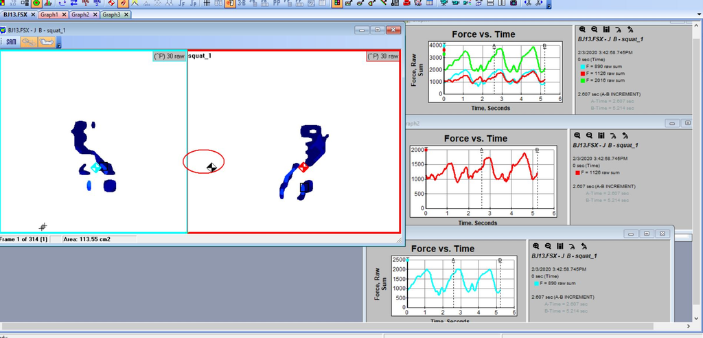

## One possibility

This can be done. One way is to use the `findpeaks` function in the pracma package. However, this can be tricky because what the function determines as peaks may not be your idea of peaks. Take the following example:

```r
sq_left <- read.csv(file = "LEAP_628_Other_041_KE/Squat1_Left_F.csv", skip = 24)
```

Here is the plot of Force for the left leg. I see about three peaks: one on the left, one in the middle, and one on the right.

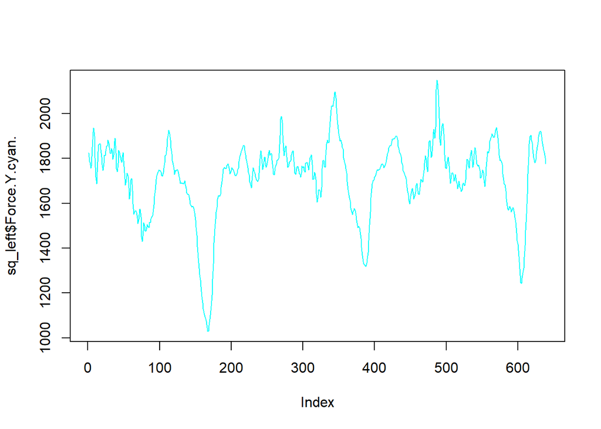

```r
plot(sq_left$Force.Y.cyan., col = "cyan", type = "l")
```

Now let’s see which three peaks the `findpeaks` function finds.

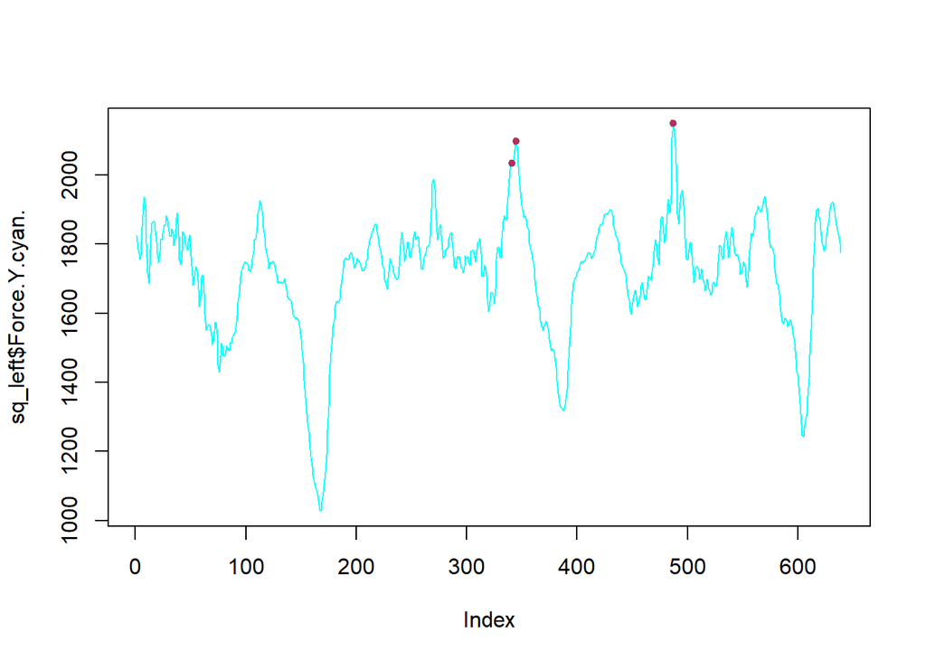

```r
library(pracma)
peaks <- findpeaks(sq_left$Force.Y.cyan., npeaks = 3, sortstr = TRUE)
plot(sq_left$Force.Y.cyan., col = "cyan", type = "l")
points(peaks[, 2], peaks[, 1], pch=20, col="maroon")
```

Probably not what we were expecting. With some tweaking we can improve peak identification. (But will this tweaking work for every subject?)

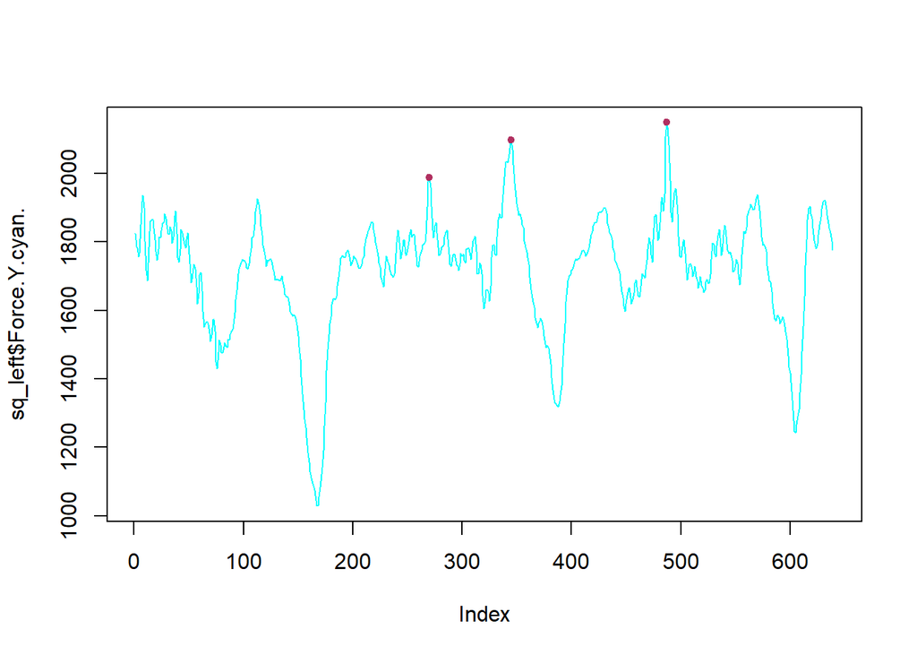

```r
peaks <- findpeaks(sq_left$Force.Y.cyan., npeaks = 3, sortstr = TRUE,
                   nups = 3, ndowns = 3)
plot(sq_left$Force.Y.cyan., col = "cyan", type = "l")
points(peaks[, 2], peaks[, 1], pch=20, col="maroon")
```

It didn’t select the “peak” on the left, but maybe that’s OK.

The right leg is even more problematic (at least for this subject). Notice the selected peaks. Are they really peaks of interest?

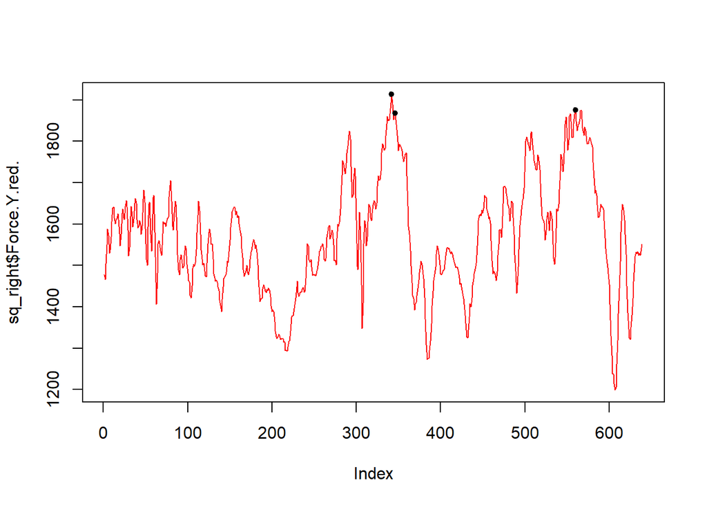

```r
sq_right <- read.csv(file = "LEAP_628_Other_041_KE/Squat1_Right_F.csv", skip = 24)
peaks <- findpeaks(sq_right$Force.Y.red., npeaks = 3, sortstr = TRUE)
plot(sq_right$Force.Y.red., col = "red", type = "l")
points(peaks[, 2], peaks[, 1], pch=20, col="black")
```